# PEAK Neo4j Data Model

Jason Preszler

April 30, 2018

# Node Types

- Course
- Major
- Minor
- PEAK
- Component - This is a sub-unit of a major of minor in which several courses could be used to satisfy a requirement.
- Instructor

# Relationship Types

- Prerequisite
- Requirement
- Option
- Satisfies
- Taught_By
- Contact - primary faculty member for questions about major, minor, course.

# Node Properties

## Courses

- id: an internally used identifier, usually combination of subject and number
- subject: the three letter subject code from the catalog
- number: the three digit course number
- url: link to catalog course entry
- name: official course name
- description: catalog description
- minCredits: number
- maxCredits: number, most courses have minCredits==maxCredits
- frequency: code for how often the course is taught as follows

  ** FS: every fall and spring ** ALL: every Fal, Winter, Spring ** W: winter only ** F: fall only ** S: spring only ** FO: Fall of odd number years ** FE: Fall of Even number years ** SO: ** SE: ** WE: ** WO: ** AN: As needed or student demand, typically internships, ind. study, and other irregular or single student courses go here.

## Major

- Name
- MinCredits

## Minor

- Name
- MinCredits

## PEAK

- name: long name of PEAK, i.e. “Natural Sciences and Mathematics”
- code: three letter code, i.e. “NSM”

## Instructor

- Name
- Email
- Office
- Dept.
- phone

## Component

- Name
- Description

# Graph

The following graph depicts the basic data model, using the igraph library in R rather than dumping the schema from Neo4j (since nothing is in Neo4j yet).

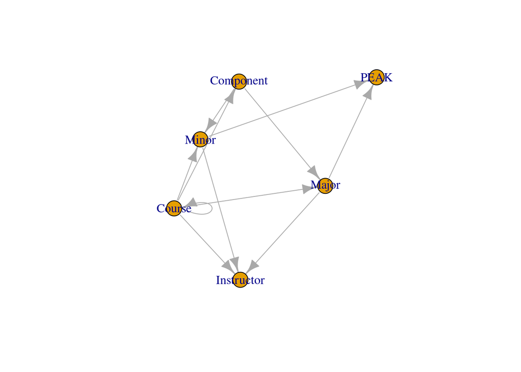

```r
library(igraph)

g <- graph.empty(6, directed=TRUE)
init_edges <- c(1,1, 1,5, 5,2, 5,3, 2,4, 3,4, 1,6, 2,6, 3,6, 1,2, 1,3)

g <- add.edges(g, init_edges)
V(g)$name <- c("Course", "Major", "Minor", "PEAK", "Component", "Instructor")

plot(g, layout=layout.fruchterman.reingold)
```

# Additional “Course Nodes”

Besides catalog courses, there are several non-course “course” nodes that will need to be added for prerequisite and major/minor requirements.

- “Instructor Permission”
- “Senior Standing”
- “Junior or Senior Standing”